# Meaning Threat and Moral Dumbfounding

Two studies on threat and worldview defense

Cillian McHugh

30th October 2020

([shared document for developing follow up studies available here](https://docs.google.com/document/d/1uZCHeWoCfA3utWq7o2IZZkI_EyQA5S0JUMCldhm6X-M/edit?usp=sharing))

# Background and Aims

- According to the Meaning Maintenance Model (Heine, Proulx, & Vohs, 2006), when people experience a threat to meaning they attempt to restore meaning through a compensatory response (Heine et al., 2006; Proulx & Heine, 2009; Proulx & Inzlicht, 2012).
- We hypothesise that being faced with the possibility of being morally dumbfounded constitutes a threat to meaning.
- This would predict that taking part in a moral dumbfounding task leads to the same kind of compensatory response as observed in response to other meaning threats.
- We test this with two studies:
  - **Study 1**: replication of an existing meaning threat study (uncertainty threat, van den Bos, Poortvliet, Maas, Miedema, & van den Ham, 2005).
  - **Study 2**: similar to Study 1, but replacing the “uncertainty” threat with a moral dumbfounding task.

# Study 1

## Background

The aim of Study 1 was to replicate the *uncertainty threat* finding by van den Bos et al. (2005). Participants completed a task that either poses an uncertainty threat (or does not – control). Following this participants read a hypothetical article about University of Limerick. This article was either positive or negative. We hypothesised that the participants in the uncertainty threat condition will display more “worldview defense” in response to the negative article than the participants in the control condition.

## Design:

2x2 Factorial design. IV1 is “salience” with 2 levels: uncertainty vs television. IV2 is article type with two levels: threat and no threat. Primary Dependent variable is “worldview defense” however measures of Anger and Sadness were taken. Need for Closure and Self-esteem were additionally measured as potential moderator variables (not investigated in this first look document).

## Participants

A final sample of 130 participant (96 female, 34 male; *M*<sub>age</sub> = 23.54, min = 18, max = 60, *SD* = 8.62) were analysed. In order to ensure the worldview threat manipulation was relevant, all particpants were recruited from the student community in University of Limerick.

## Materials and Procedure:

### Salience / Uncertainty Manipulation

“Salience” was manipulated by presenting participants with either of the following instructions:

1. ‘‘Please briefly describe the emotions that the thought of your being uncertain arouses in you,’’ and
2. ‘‘Please write down, as specifically as you can, what you think physically will happen to you as you feel uncertain.’’

Or for the control group:

1. ‘‘Please briefly describe the emotions that the thought watching television arouses in you,’’ and
2. ‘‘Please write down, as specifically as you can, what you think physically will happen to you as you watch television.’’

### Worldview threat/defense

> Last year, I took a course at University of Limerick. I had been looking for an opportunity to take some classes elsewhere and there happened to be a course at University of Limerick that was relevant for my major. So, I signed up for the course, bought the textbook, and went to University of Limerick twice a week for a period of three months. Lectures were well taught and there was ample room to ask questions. It was fun attending the seminars. We had to complete assignments in small groups and it was great working together with these University of Limerick students. Interactions with teachers and students were excellent, so I did not have to adapt to another environment or something like that. The teaching was not very different from teaching at UCD, so I passed the exam with no difficulty. If you are interested in doing so, I certainly would like to recommend to take a course somewhere outside of UCD someday!

> Last year, I took a course at University of Limerick. That was a complete disaster! During lectures all students were talking out loud, so I hardly could follow the lectures. Seminars hit an all time low. I was getting the impression that everyone over there were just serving their time. The standards of these University of Limerick students are really low: No one prepares anything and no one asks interesting questions. Worst of all was the fact that I had to complete assignments with a couple of those students. It was very hard working together with those kind of people! If they showed up at all, they only made stupid remarks. Fortunately, things are much better here at UCD. The students over here are motivated and really interested in discussions. The only positive thing of my Utrecht experience was that I passed the exam, so that I do not have to see these University of Limerick students again!

### “Worldview Defense” Measure

There were eight “Worldview Defense” questions.

1. How angry do you feel at this moment? (1 = *not at all angry*, 7 = *very angry*)
2. How hostile do you feel at this moment? (1 = *not at all hostile*, 7 = *very hostile*)
3. How furious do you feel at this moment? (1 = *not at all furious*, 7 = *very furious*)
4. How infuriated do you feel at this moment? (1 = *not at all infuriated*, 7 = *very infuriated*)
5. How sad do you feel at this moment (1 = *very weak*, 7 = *very strong*)
6. How disappointed do you feel at this moment? (1 = *very weak*, 7 = *very strong*)
7. To what extent do you disagree or agree with the general idea of the person in the article (1 = *strongly disagree*, 7 = *strongly agree*)
8. To what extent do you disagree or agree with the remarks of the person with respect to content (1 = *strongly disagree*, 7 = *strongly agree*)

## Results

Worldview defense was significantly higher for the threat condition than for the no threat condition. Salience (uncertainty vs control) did not have a significant influence. There was no interaction between Salience and Threat.

Table 1:

*Study 1: descriptive statistics for Worldview Defense by condition*

| Salience | Threat | mean | sd | min | max | len |
| --- | --- | --- | --- | --- | --- | --- |
| Control | No Threat | 1.86 | 0.87 | 1.00 | 5.38 | 32 |
| Control | Threat | 3.46 | 1.09 | 1.62 | 5.50 | 31 |
| Uncertainty | No Threat | 1.83 | 0.75 | 1.00 | 4.00 | 31 |
| Uncertainty | Threat | 3.52 | 1.13 | 1.62 | 5.50 | 36 |

Table 2:

*Study 1: ANOVA table for the analyis of the example data set.*

| Effect | $F$ | $\mathit{df}_1$ | $\mathit{df}_2$ | $\mathit{MSE}$ | $p$ | $\hat{\eta}^2_p$ |
| --- | --- | --- | --- | --- | --- | --- |
| Salience | 0.01 | 1 | 126 | 0.96 | .916 | .000 |
| Threat | 91.50 | 1 | 126 | 0.96 | < .001 | .421 |
| Salience $\times$ Threat | 0.05 | 1 | 126 | 0.96 | .821 | .000 |

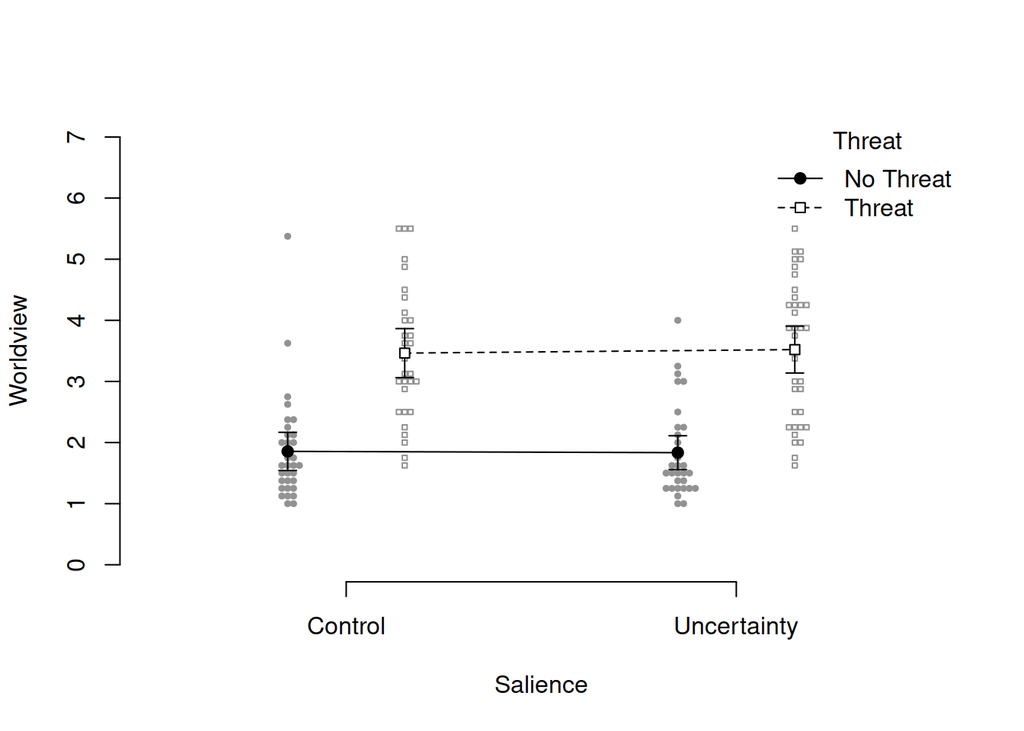

Figure 1: Study 1: Worldview Defense score depending on condition

# Study 2

## Background

Study 2 was an extension of Study 1, however the uncertainty threat will be replaced by a moral dumbfounding task (McHugh et al., 2017). The control will be replaced with a moral task that is not as challenging as a dumbfounding task. We hypothesised that participants in the dumbfounding condition will display more “worldview defense” in response to the negative article than the participants in the moral judgement condition.

## Design:

2x2 Factorial design. IV1 is “threat level” with 2 levels: high (dumbfounding) vs low (moral judgement). IV2 is article type with two levels: threat and no threat. Primary Dependent variable is “worldview defense” however measures of Anger and Sadness will also be taken. Need for Closure and Self-esteem will be additionally measured as potential moderator variables.

## Participants

A final sample of 173 participant (110 female, 63 male; *M*<sub>age</sub> = 22.05, min = 18, max = 57, *SD* = 6.01) were analysed. In order to ensure the worldview threat manipulation was relevant, all particpants were recruited from the student community in University of Limerick.

### Moral dumbfounding task:

Participants were then presented with the target moral scenario, the “Julie and Mark” (Incest) vignette (See below), taken from the original moral dumbfounding study (Haidt, Björklund, & Murphy, 2000).

Participants were asked to rate, on a 7-point Likert scale, how right or wrong the behaviour of Julie and Mark was (where, 1 = Morally wrong; 4 = Neutral; 7 = Morally right). They were then provided with an open ended response option and asked to provide a reason for their judgement. They then rated their confidence in their judgement. Following this, participants were presented with a series of counter-arguments, which refute commonly used justifications for rating the behaviour as “wrong” (see below). After each counter-argument, participants were asked “Do you (still) think it is wrong?”, with a binary “yes/no” response option; and then they were asked “Do you have a reason for your judgement?”, with three possible response options “Yes, I have a reason”, “No I have no reason”, and “Unsure”.

#### Measuring Dumbfounding

Dumbfounding was measured using the critical slide. The critical slide contains a statement defending the behaviour and a question as to how the behaviour could be wrong

> “Julie and Mark’s behaviour did not harm anyone, how can there be anything wrong with what they did?”.

There are three possible answer options: (a) “There is nothing wrong”; (b) an admission of not having reasons (“It’s wrong but I can’t think of a reason”); and finally a judgement with accompanying justification (c) “It’s wrong and I can provide a valid reason”.

The order of these response options will be randomised. Participants who select (c) will be prompted on the following slide to type a reason. The selecting of option (b), the admission of not having reasons, will be taken to be a dumbfounded response.

#### Follow-up Measures

Following the critical slide, participants will rate the behaviour, and their confidence in their judgement again. They will also be asked to indicate, on a 7-point Likert scale, how much they had changed their mind. They will also asked to rate on a 7-point Likert scale how difficult they found the memory task. Following this a post-discussion questionnaire, taken from Haidt et al. (2000) will be administered (see below).

## Materials

### Dumbfounding

#### Dumbfounding: Julie and Mark vignette

(Taken from Haidt et al., 2000)

> Julie and Mark, who are brother and sister are travelling together in France. They are both on summer vacation from college. One night they are staying alone in a cabin near the beach. They decide that it would be interesting and fun if they tried making love. At very least it would be a new experience for each of them. Julie was already taking birth control pills, but Mark uses a condom too, just to be safe. They both enjoy it, but they decide not to do it again. They keep that night as a special secret between them, which makes them feel even closer to each other.

#### Dumbfounding: counter-arguments

- Do you not agree that any concerns regarding reproductive complications are eased by their using of two forms of contraception?
- Do you accept that they are both consenting adults, and that they both consented and enjoyed it?
- And do you concede that nobody else was affected by their actions?

#### Dumbfounding: Critical Slide

> Julie and Mark’s actions did not harm anyone, or negatively affect anyone. How can there be anything wrong with what they did?
1. It’s wrong and I can provide a valid reason.
2. It’s wrong but I can’t think of a reason.
3. There is nothing wrong.

### Moral judgement task:

#### Moral judgement: Arnold Paxton (adapted from Wheatley & Haidt, 2005)

> Congressman Arnold Paxton frequently gives speeches condemning corruption and arguing for campaign finance reform. But he is just trying to cover up the fact that he himself will take bribes from special interest and lobby groups, to promote their legislation. He has recently come to a lucrative arrangement with a tobacco lobby group. There is new legislation being proposed that aims to reduce underage smoking, and Arnold intends to oppose this.

#### Moral judgement: counter-arguments

- Do you not agree Arnold’s speaking against corruption will reduce corruption?
- Do you think it is possible that Arnold may need to appease the tobacco lobby on this occasion in order to achieve a longer term agenda?
- And do you accept that nobody people should be allowed to make their own choices regarding the use of tobacco products?

#### Moral judgement: Critical Slide

> Arnold’s actions defended the right of the individual to make up their own mind regarding the use of tobacco products. How can there be anything wrong with what he did?
1. It’s wrong and I can provide a valid reason.
2. It’s wrong but I can’t think of a reason.
3. There is nothing wrong.

### Worldview threat/defense

This was manipulated and measured using the same procedure as Study 1.

## Results

Worldview defense was significantly higher for the threat condition than for the no threat condition. The type of task (dumbfounding vs judgement) did not have a significant influence. There was no interaction between Condition and Threat.

Table 3:

*Study 2: descriptive statistics for Worldview Defense by condition*

| Condition | Threat | mean | sd | min | max | len |
| --- | --- | --- | --- | --- | --- | --- |
| Control | No Threat | 1.77 | 0.72 | 1.00 | 3.88 | 37 |
| Control | Threat | 3.57 | 1.36 | 1.50 | 6.25 | 40 |
| Dumbfounding | No Threat | 1.70 | 0.60 | 1.00 | 3.62 | 47 |
| Dumbfounding | Threat | 3.35 | 1.17 | 1.38 | 6.00 | 49 |

Table 4:

*Study 2: ANOVA table for the analyis of the example data set.*

| Effect | $F$ | $\mathit{df}_1$ | $\mathit{df}_2$ | $\mathit{MSE}$ | $p$ | $\hat{\eta}^2_p$ |
| --- | --- | --- | --- | --- | --- | --- |
| Condition | 0.92 | 1 | 169 | 1.02 | .340 | .005 |
| Threat | 123.90 | 1 | 169 | 1.02 | < .001 | .423 |
| Condition $\times$ Threat | 0.23 | 1 | 169 | 1.02 | .633 | .001 |

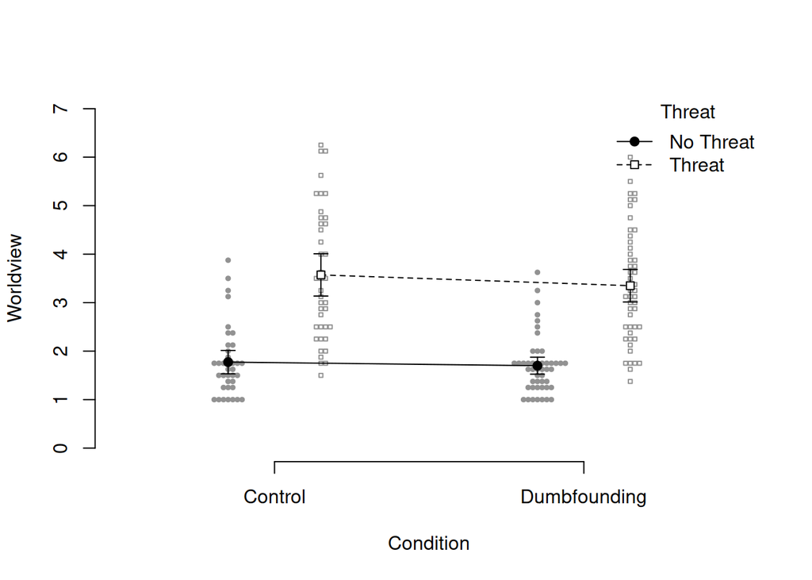

Figure 2: Study 2: Worldview Defense score depending on condition

### Alternative analysis

Given that dumbfounding was the condition of interest, and both moral judgement tasks measured dumbfounded responding, a follow up analysis replaced the Condition as the IV with the response to the critical slide as the IV.

In this alternative analysis, Worldview defense was significantly higher for the threat condition than for the no threat condition. Response to the critical slide (dumbfounding vs judgement) did not have a significant influence. There was no interaction between Response to the critical slide and Threat.

Table 5:

*Study 2: descriptive statistics for Worldview Defense by condition and response to Critical Slide*

| Threat | Dumbfounded | mean | sd | min | max | len |
| --- | --- | --- | --- | --- | --- | --- |
| No Threat | Dumbfounded | 1.70 | 0.86 | 1.00 | 3.88 | 10 |
| No Threat | Nothing Wrong | 1.71 | 0.80 | 1.00 | 3.62 | 9 |
| No Threat | Reasons | 1.74 | 0.60 | 1.00 | 3.50 | 65 |
| Threat | Dumbfounded | 4.01 | 1.37 | 1.62 | 6.12 | 20 |
| Threat | Nothing Wrong | 3.59 | 1.49 | 1.75 | 6.25 | 7 |
| Threat | Reasons | 3.25 | 1.16 | 1.38 | 6.12 | 62 |

Table 6:

*Study 2: ANOVA table for the analyis of the example data set.*

| Effect | $F$ | $\mathit{df}_1$ | $\mathit{df}_2$ | $\mathit{MSE}$ | $p$ | $\hat{\eta}^2_p$ |
| --- | --- | --- | --- | --- | --- | --- |
| Dumbfounded | 1.47 | 2 | 167 | 0.99 | .234 | .017 |
| Threat | 75.28 | 1 | 167 | 0.99 | < .001 | .311 |
| Dumbfounded $\times$ Threat | 1.84 | 2 | 167 | 0.99 | .162 | .022 |

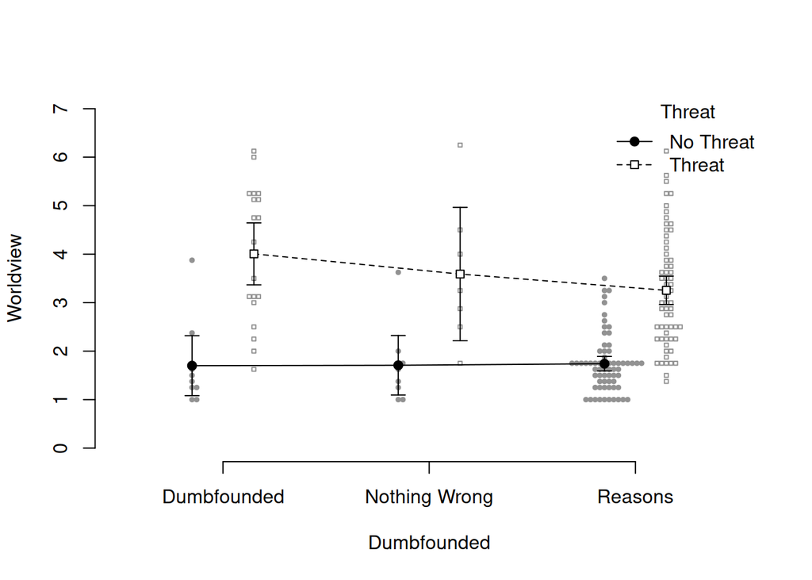

Figure 3: Study 2: Worldview Defense score depending on condition and response to Critical Slide

## Additional Analysis

### Confidence

#### Initially:

- How confident are you in the judgement you have made?

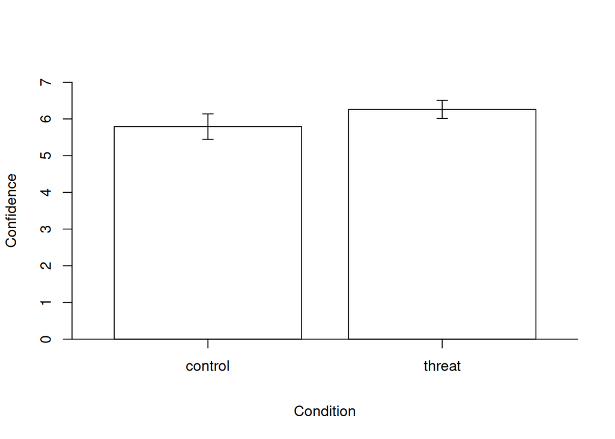

Figure 4: Study 2: Confidence score depending on condition

Table 7:

*Descriptive statistics for Confidence Scores by Condition*

|  | mean | sd | min | max | len |
| --- | --- | --- | --- | --- | --- |
| control | 5.79 | 1.52 | 1.00 | 7.00 | 77 |
| threat | 6.26 | 1.22 | 1.00 | 7.00 | 96 |

$\Delta M = -0.47$, 95% CI $[-0.89$, $-0.05]$, $t(143.46) = -2.19$, $p = .030$

#### Revised:

- How confident are you in the judgement you have made?

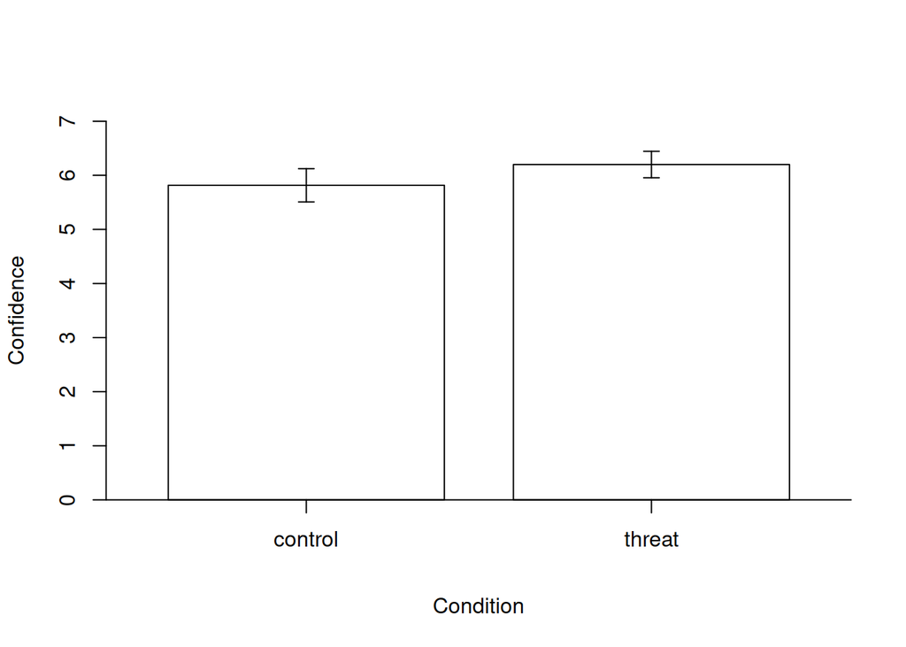

Figure 5: Study 2: Confidence score depending on condition

Table 8:

*Descriptive statistics for Confidence Scores by Condition*

|  | mean | sd | min | max | len |
| --- | --- | --- | --- | --- | --- |
| control | 5.82 | 1.34 | 2.00 | 7.00 | 76 |
| threat | 6.20 | 1.20 | 2.00 | 7.00 | 95 |

$\Delta M = -0.38$, 95% CI $[-0.77$, $0.01]$, $t(151.85) = -1.95$, $p = .053$

### Dumbfounding and Defense

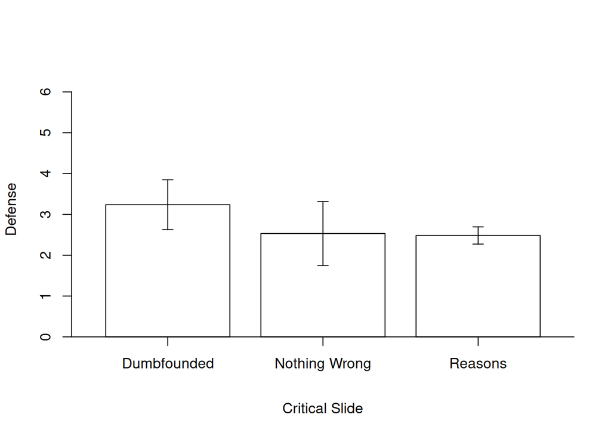

Figure 6: Study 2: Defense score depending on response to Critical Slide

Table 9:

|  | mean | sd | min | max | len |
| --- | --- | --- | --- | --- | --- |
| Dumbfounded | 3.24 | 1.64 | 1.00 | 6.12 | 30 |
| Reasons | 2.48 | 1.19 | 1.00 | 6.12 | 125 |
| Nothing Wrong | 2.53 | 1.47 | 1.00 | 6.25 | 16 |

Table 10:

*ANOVA table*

| Effect | $F$ | $\mathit{df}_1$ | $\mathit{df}_2$ | $\mathit{MSE}$ | $p$ | $\hat{\eta}^2_G$ |
| --- | --- | --- | --- | --- | --- | --- |
| InCS neat | 4.08 | 2 | 168 | 1.70 | .019 | .046 |

Table 11:

*Tukey’s Pairwise comparisons*

|  | diff | lwr | upr | p adj |
| --- | --- | --- | --- | --- |
| Nothing Wrong-Dumbfounded | -0.71 | -1.66 | 0.25 | 0.19 |
| Reasons-Dumbfounded | -0.75 | -1.38 | -0.13 | 0.01 |
| Reasons-Nothing Wrong | -0.05 | -0.87 | 0.77 | 0.99 |

### Dumbfounding and Scenario

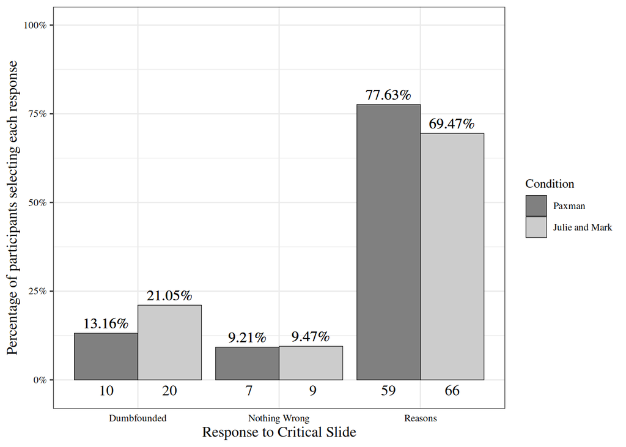

A chi-squared test for independence revealed no significant association between experimental condition and response to the critical slide, $\chi$<sup>2</sup>(2, *N* = 171) = 1.888, *p* = .389, *V* = 0.11, the observed power was 0.21.

# Data Accessibility Statement

All participant data, and analysis scripts, along with the pre-registered methods and hypotheses, will be available this paper’s project page on the Open Science Framework at https://osf.io/ubmvs/.

All statistical analysis was conducted using R (Version 4.0.3; R Core Team, 2017) and the R-packages *afex* (Version 0.27.2; Singmann, Bolker, Westfall, & Aust, 2017), *data.table* (Version 1.13.0; Dowle & Srinivasan, 2020), *desnum* (Version 0.1.1; McHugh, 2017), *dplyr* (Version 1.0.1; Wickham, Francois, Henry, & Müller, 2017), *forcats* (Version 0.5.0; Wickham, 2020), *foreign* (Version 0.8.80; R Core Team, 2018), *ggplot2* (Version 3.3.2; Wickham, 2009), *haven* (Version 2.3.1; Wickham & Miller, 2020), *lme4* (Version 1.1.23; Bates, Mächler, Bolker, & Walker, 2015), *Matrix* (Version 1.2.18; Bates & Maechler, 2019), *papaja* (Version 0.1.0.9997; Aust & Barth, 2020), *purrr* (Version 0.3.4; Henry & Wickham, 2020), *pwr* (Version 1.3.0; Champely, 2018), *readr* (Version 1.3.1; Wickham et al., 2018), *reshape2* (Version 1.4.4; Wickham, 2007), *scales* (Version 1.1.1; Wickham, 2018), *stringr* (Version 1.4.0; Wickham, 2019), *tibble* (Version 3.0.3; Müller & Wickham, 2017), *tidyr* (Version 1.1.1; Wickham & Henry, 2020), and *tidyverse* (Version 1.3.0; Wickham, Averick, et al., 2019).

# References

Aust, F., & Barth, M. (2020). *Papaja: Create APA manuscripts with R Markdown*. Manual.

Bates, D., & Maechler, M. (2019). *Matrix: Sparse and Dense Matrix Classes and Methods*.

Bates, D., Mächler, M., Bolker, B., & Walker, S. (2015). Fitting Linear Mixed-Effects Models Using lme4. *Journal of Statistical Software*, *67*(1), 1–48. https://doi.org/10.18637/jss.v067.i01

Champely, S. (2018). *Pwr: Basic Functions for Power Analysis*.

Dowle, M., & Srinivasan, A. (2020). *Data.Table: Extension of ‘data.Frame‘*. Manual.

Heine, S. J., Proulx, T., & Vohs, K. D. (2006). The Meaning Maintenance Model: On the Coherence of Social Motivations. *Personality and Social Psychology Review*, *10*(2), 88–110. https://doi.org/10.1207/s15327957pspr1002_1

Henry, L., & Wickham, H. (2020). *Purrr: Functional programming tools*. Manual.

McHugh, C. (2017). *Desnum: Creates some useful functions*. Manual.

McHugh, C., McGann, M., Igou, E. R., & Kinsella, E. L. (2017). Searching for Moral Dumbfounding: Identifying Measurable Indicators of Moral Dumbfounding. *Collabra: Psychology*, *3*(1), 1–24. https://doi.org/10.1525/collabra.79

Müller, K., & Wickham, H. (2017). *Tibble: Simple Data Frames*.

Proulx, T., & Heine, S. J. (2009). Connections From Kafka Exposure to Meaning Threats Improves Implicit Learning of an Artificial Grammar. *Psychological Science*, *20*(9), 1125–1131. https://doi.org/10.1111/j.1467-9280.2009.02414.x

Proulx, T., & Inzlicht, M. (2012). The Five “A”s of Meaning Maintenance: Finding Meaning in the Theories of Sense-Making. *Psychological Inquiry*, *23*(4), 317–335. https://doi.org/10.1080/1047840X.2012.702372

R Core Team. (2017). *R: A Language and Environment for Statistical Computing*. Vienna, Austria: R Foundation for Statistical Computing.

R Core Team. (2018). *Foreign: Read Data Stored by ’Minitab’, ’S’, ’SAS’, ’SPSS’, ’Stata’, ’Systat’, ’Weka’, ’dBase’, ...*

Singmann, H., Bolker, B., Westfall, J., & Aust, F. (2017). *Afex: Analysis of Factorial Experiments*.

van den Bos, K., Poortvliet, P. M., Maas, M., Miedema, J., & van den Ham, E.-J. (2005). An enquiry concerning the principles of cultural norms and values: The impact of uncertainty and mortality salience on reactions to violations and bolstering of cultural worldviews. *Journal of Experimental Social Psychology*, *41*(2), 91–113. https://doi.org/10.1016/j.jesp.2004.06.001

Wickham, H. (2007). Reshaping data with the reshape package. *Journal of Statistical Software*, *21*(12), 1–20.

Wickham, H. (2009). *Ggplot2: Elegant Graphics for Data Analysis*. Springer-Verlag New York.

Wickham, H. (2018). *Scales: Scale Functions for Visualization*.

Wickham, H. (2019). *Stringr: Simple, consistent wrappers for common string operations*. Manual.

Wickham, H. (2020). *Forcats: Tools for working with categorical variables (factors)*. Manual.

Wickham, H., Averick, M., Bryan, J., Chang, W., McGowan, L. D., François, R., … Yutani, H. (2019). Welcome to the tidyverse. *Journal of Open Source Software*, *4*(43), 1686. https://doi.org/10.21105/joss.01686

Wickham, H., Francois, R., Henry, L., & Müller, K. (2017). *Dplyr: A Grammar of Data Manipulation*.

Wickham, H., & Henry, L. (2020). *Tidyr: Tidy messy data*. Manual.

Wickham, H., Hester, J., & Francois, R. (2018). *Readr: Read rectangular text data*. Manual.

Wickham, H., & Miller, E. (2020). *Haven: Import and export ’SPSS’, ’stata’ and ’SAS’ files*. Manual.